# Session 5: Causation vs. Correlation — Live Demo

Advanced Data Science · Europa-Universität Flensburg

Author

Claudius Gräbner-Radkowitsch

Published

21 05 2026

# 1 Setup

## 1.1 Business question

> *Is there a gender wage gap among US workers? And what would it take to interpret a regression coefficient as evidence of discrimination?*

## 1.2 Packages and data

```r
library(tidyverse)
library(broom)
library(modelsummary)
library(patchwork)

raw <- read_csv("data/morg-2014-emp.csv", show_col_types = FALSE)
```

The raw file contains 149316 observations with 23 variables from the CPS MORG. We keep only what we need and construct the relevant variables:

```r
cps <- raw |>
  filter(
    !is.na(earnwke), earnwke > 0,
    !is.na(uhours),  uhours  > 0,
    !is.na(occ2012), !is.na(grade92),
    !is.na(age), !is.na(sex)
  ) |>
  mutate(
    wage   = earnwke / uhours,
    female = as.integer(sex == 2),
    educ   = grade92,
    occ    = factor(occ2012)
  ) |>
  filter(wage > 0, wage < 500) |>
  select(wage, female, age, educ, occ)

glimpse(cps)
```

```
Rows: 149,306
Columns: 5
$ wage   <dbl> 42.30000, 11.25000, 18.16667, 19.23075, 20.67300, 22.00000, 9.0…
$ female <int> 1, 1, 0, 0, 1, 0, 1, 1, 0, 0, 1, 1, 0, 1, 0, 0, 1, 0, 1, 1, 1, …
$ age    <dbl> 29, 27, 30, 48, 46, 29, 25, 36, 56, 49, 50, 39, 42, 25, 39, 57,…
$ educ   <dbl> 43, 41, 41, 40, 43, 39, 39, 44, 39, 46, 43, 39, 40, 35, 41, 41,…
$ occ    <fct> 630, 5400, 8140, 8255, 5940, 6200, 5100, 2200, 5530, 1530, 3050…
```

We have 149306 workers after cleaning. The median hourly wage is $19.62 for men and $16.15 for women — a raw gap of 17.7%.

# 2 The raw picture

## 2.1 Summary statistics by gender

```r
cps |>
  mutate(gender = if_else(female == 1, "Female", "Male")) |>
  group_by(gender) |>
  summarise(
    N            = n(),
    `Median wage`  = median(wage)    |> round(2),
    `Mean wage`    = mean(wage)      |> round(2),
    `SD wage`      = sd(wage)        |> round(2),
    `Median age`   = median(age),
    `Median educ`  = median(educ)
  )
```

```
# A tibble: 2 × 7
  gender     N `Median wage` `Mean wage` `SD wage` `Median age` `Median educ`
  <chr>  <int>         <dbl>       <dbl>     <dbl>        <dbl>         <dbl>
1 Female 73734          16.2        20.2      14.4           41            41
2 Male   75572          19.6        23.9      15.2           40            40
```

## 2.2 Wage distribution by gender

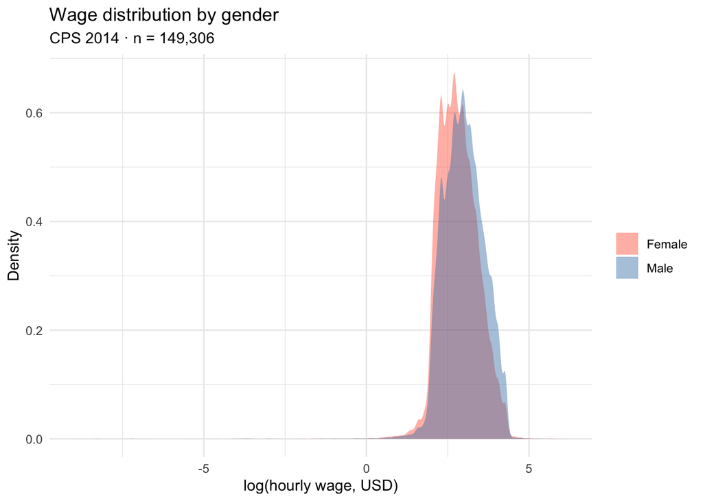

Figure 1: Log wage distributions by gender. The female distribution sits to the left — but the overlap is large.

```r
cps |>
  mutate(gender = if_else(female == 1, "Female", "Male")) |>
  ggplot(aes(log(wage), fill = gender)) +
  geom_density(alpha = 0.45, colour = NA) +
  scale_fill_manual(values = c("Female" = "tomato", "Male" = "steelblue")) +
  labs(
    x     = "log(hourly wage, USD)",
    y     = "Density",
    fill  = NULL,
    title = "Wage distribution by gender",
    subtitle = paste0("CPS 2014 · n = ", format(n_obs, big.mark = ","))
  ) +
  theme_minimal()
```

There is a clear leftward shift for women, but the distributions overlap substantially. Before concluding this is discrimination, we need to ask: *what else differs between men and women in this sample?*

# 3 Three models, three questions

The core claim of this session: every regression answers a specific question. The question changes when you add or remove controls. This is not a matter of some models being “more controlled” — it is a matter of which causal pathway you are estimating.

## 3.1 Estimating the models

```r
m1 <- lm(log(wage) ~ female,                    data = cps)
m2 <- lm(log(wage) ~ female + age + educ,        data = cps)
m3 <- lm(log(wage) ~ female + age + educ + occ,  data = cps)
```

## 3.2 The side-by-side comparison

```r
modelsummary(
  list(
    "Model 1: Raw gap"        = m1,
    "Model 2: + Demographics" = m2,
    "Model 3: + Occupation"   = m3
  ),
  coef_map = c(
    "female" = "Female",
    "age"    = "Age",
    "educ"   = "Education (grade92)"
  ),
  gof_omit = "AIC|BIC|Log|F|RMSE",
  stars    = TRUE,
  notes    = "Occupation dummies (Model 3) omitted from display."
)
```

Table 1: Three models of the gender wage gap. Outcome: log(hourly wage).

|  | Model 1: Raw gap | Model 2: + Demographics | Model 3: + Occupation |
| --- | --- | --- | --- |
| Female | -0.164*** | -0.212*** | -0.138*** |
|  | (0.003) | (0.003) | (0.003) |
| Age |  | 0.012*** | 0.009*** |
|  |  | (0.000) | (0.000) |
| Education (grade92) |  | 0.109*** | 0.060*** |
|  |  | (0.001) | (0.001) |
| Num.Obs. | 149306 | 149306 | 149306 |
| R2 | 0.016 | 0.271 | 0.384 |
| R2 Adj. | 0.016 | 0.271 | 0.382 |

+ p < 0.1, * p < 0.05, ** p < 0.01, *** p < 0.001  
Occupation dummies (Model 3) omitted from display.

The female coefficient moves from -0.164 (Model 1) to -0.212 (Model 2) to -0.138 (Model 3). **This does not mean Model 3 is the most correct.** Each model answers a different question.

# 4 DAG-based interpretation

## 4.1 What each model claims

**Model 1 — the raw gap**

$$\log(\text{wage}_i) = \alpha + \beta_1 \cdot \text{female}_i + \varepsilon_i$$

This is a pure descriptive statement: female workers earn, on average, 16.4% less per hour in log terms. It makes no causal claim. The coefficient absorbs everything that co-varies with gender: age, education, occupation, unobserved family background, and actual pay discrimination.

**Model 2 — controlling for demographics**

$$\log(\text{wage}_i) = \alpha + \beta_1 \cdot \text{female}_i + \beta_2 \cdot \text{age}_i + \beta_3 \cdot \text{educ}_i + \varepsilon_i$$

Age and education are plausible confounders: they affect wages and are systematically related to gender (the sample shows some difference in educational composition). Adding them closes those back-door paths — but only if age and education are truly confounders and not mediators.

**Note**

Are age and education confounders or mediators here? They are treated as confounders — they affect wages independently of gender, and they are not caused by gender. This is defensible if we think of “gender” as a fixed attribute the worker enters the labour market with.

**Model 3 — adding occupation**

$$\log(\text{wage}_i) = \alpha + \beta_1 \cdot \text{female}_i + \beta_2 \cdot \text{age}_i + \beta_3 \cdot \text{educ}_i + \sum_k \gamma_k \cdot \text{occ}_{ik} + \varepsilon_i$$

This is the key model — and the key trap.

If gender discrimination causes occupational sorting (women are pushed toward lower-paying occupations by social and structural forces), then occupation is a **mediator**: it lies *on the causal path* from gender to wage. Controlling for it blocks part of the very effect we are trying to measure.

The coefficient -0.138 is not a more precise estimate of discrimination. It is an estimate of the pay gap **within** occupation groups — the direct channel of discrimination, net of occupational sorting. Whether that narrower quantity is what we want depends entirely on the research question.

## 4.2 The bad control in plain terms

**Important**

**The bad control lesson:** Adding occupation does not make the estimate better. It answers a different question: *“Do women earn less than men in the same occupation, at the same age and education level?”* That is sometimes the right question. But if we want to know the total effect of gender on wages — including the sorting mechanism — Model 3 gives us the wrong answer, not a better one.

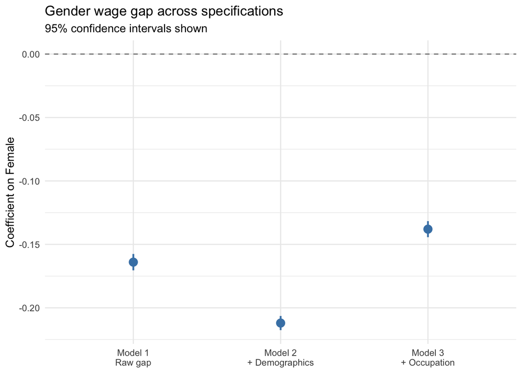

Figure 2: The gender coefficient across three models. The shrinkage from Model 2 to Model 3 is not precision — it is a change in the question being answered.

```r
tibble(
  model = factor(
    c("Model 1\nRaw gap", "Model 2\n+ Demographics", "Model 3\n+ Occupation"),
    levels = c("Model 1\nRaw gap", "Model 2\n+ Demographics", "Model 3\n+ Occupation")
  ),
  estimate = c(gap_m1, gap_m2, gap_m3),
  se       = c(
    summary(m1)$coefficients["female", "Std. Error"],
    summary(m2)$coefficients["female", "Std. Error"],
    summary(m3)$coefficients["female", "Std. Error"]
  )
) |>
  ggplot(aes(model, estimate)) +
  geom_hline(yintercept = 0, linetype = "dashed", colour = "gray50") +
  geom_pointrange(
    aes(ymin = estimate - 1.96 * se, ymax = estimate + 1.96 * se),
    colour = "steelblue", linewidth = 0.8, size = 0.7
  ) +
  labs(
    x     = NULL,
    y     = "Coefficient on Female",
    title = "Gender wage gap across specifications",
    subtitle = "95% confidence intervals shown"
  ) +
  theme_minimal()
```

# 5 The identification gap

## 5.1 Why none of these models proves discrimination

Each model is a conditional association. Even Model 2 — our best effort at controlling for observable confounders — cannot rule out unobserved differences between men and women that drive both wages and are correlated with gender: differences in negotiation behaviour, network access, industry composition, or employer-level pay-setting practices, for example.

An **identification argument** would need to claim: *“The variation in gender I am exploiting is as good as random with respect to wages, conditional on my controls.”* No observational regression on this data can make that claim credibly.

**Note**

This is not a failure of the data or the technique. It is a property of the question. Gender is not randomly assigned, and the labour market is not an experiment.

## 5.2 What would help?

Two strategies introduced in upcoming sessions address similar problems:

- **Panel fixed effects (Session 6):** if we had panel data on the same workers over time, we could control for *all* stable unobserved worker-level characteristics. This would eliminate time-invariant confounders but not time-varying ones.
- **Randomised experiments (Session 7):** résumé audit studies — randomly assigning gender-signalling names to identical applications — provide clean causal identification of name-based discrimination. This is a real identification strategy for *one* narrow channel of the gap.

Neither strategy eliminates all confounding for the full gender wage gap. The point is that credibility comes from the *research design*, not from adding more controls.

# 6 Summary

| Model | Controls | Question answered | Causal? |
| --- | --- | --- | --- |
| 1 | None | Average raw difference in log wages | No — pure association |
| 2 | Age, education | Gap net of demographic composition | Partially — if no unobserved confounders |
| 3 | + Occupation | Gap within occupation, conditional on demographics | Different question — occupation is a mediator |